# Homework 2 - Group 46

Name and Surname: Alessandra Colaiocco - ID: 1843714 - Email: colaiocco.1843714@studenti.uniroma1.it Name and Surname: Gabriele Parisini - ID: 1964381 - Email: parisini.1964381@studenti.uniroma1.it

# A/B tests and Confidence Sequences

## Exercise 1: Design a simulation to compare CSs and CIs

It’s common practice in web-marketing to run large-scale randomized experiments called **A/B tests**. They consist in redirecting the traffic whether to one of two different versions of a website/video/media. Several data is registered, such as the *Click-Through Rate* and the *Time spent on-site*.
This permits to test if one of the two versions is more effective than the other.
These experiments are **sequential**, meaning that the sample size is not fixed in advance: sampling is stopped in accordance with a pre-defined **stopping rule** (as soon as significant results are observed). So, using inferential methods that assume a fixed sample size is a **really bad idea** because it leads to p-hacking.
To be more specific, using a **Confidence Interval** to sequentially estimate a population parameter from a sequence of IID data (**observed sequentially**) may be restrictive: the sample size must be fixed beforehand and it is impossible to know *a priori* if the selected sample size will be large enough to detect some signal of interest.
Instead, **Confidence Sequences** are more suitable: they can be updated whenever new data become available (sample size is chosen data-adaptively), without affecting the chosen coverage level. This makes possible to continuously monitor and adaptively stop the experiment (even at *data-dependent* times). A **Confidence Sequence** is a sequence of confidence intervals such that the coverage probability is equal to $1-\alpha$ uniformly over time.
Given a sequence of IID observations from a 1-sub-Gaussian distribution (a distribution which tails decay at least as fast as those of a standard Gaussian distribution) the $1-\alpha$ confidence sequence for the population mean $\mu$ is:
$$\begin{align}
\frac{\sum_{i=1}^t X_i}{t} \pm 1.7 \cdot
\sqrt{\frac{\log(\log(2t))+0.72\log(5.2/\alpha)}{t}}
\end{align}$$
Since this specific confidence sequence is *non-asymptotic*, it requires strong assumptions on the distribution of the data. So, the following *asymptotic* confidence sequence is introduced (suitable when the data distribution is asymptotically 1-Sub-Gaussian):
$$\begin{align}
\frac{\sum_{i=1}^t X_i}{t} \pm \hat{\sigma}_t \cdot 1.7 \cdot
\sqrt{\frac{\log(\log(2t))+0.72\log(5.2/\alpha)}{t}}
\end{align}$$
where $\hat{\sigma}_t$ is the sample variance at time t.
Our job is to design a simulation to **compare the performance of the two introduced CSs with the classic CIs** (like Normal, Hoeffding, Chebyshev, etc.). Before performing the simulations, it is crucial to choose the following items:

- one or two suitable populations to sample from
- the simulation size ($M$)
- the target level ($\alpha$)
- the minimum and maximum sample sizes ($t_{min}$ and $t_{max}$)
- some metrics to evaluate

To choose any suitable population for the simulation, it is crucial to understand what does it mean that a distribution is 1-Sub-Gaussian. Generally a process $S_t$ is said to be $l_0$-Sub-$\psi$ with variance process $V_t$ (where $l_0 \geq 1$ and $\psi$ is a function with support $[0,\lambda_{max})$) if $\forall \lambda \in [0,\lambda_{max})$ there exists a supermartingale $L_t(\lambda)$ such that:

- $L_0(\lambda) \leq l_0$ a.s. (almost surely)
- $\exp\{\lambda S_t - \psi(\lambda)V_t\} \leq L_t(\lambda)$ a.s. $\forall t$

To be more precise, $S_t$ is said to be $l_0$-Sub-Gaussian if it is Sub-$\psi_N$, where:
$$\begin{align}
\psi_N = \frac{\lambda^2}{2} \quad \text{for} \; 0 \leq \lambda \leq
\infty (= \lambda_{max})
\end{align}$$

This translates to saying that the real-valued random variable $X$ is said to be $l_0$-Sub-Gaussian if:
$$\begin{align}
\mathbb{E}[\exp(t\cdot X)] \leq \exp\left(\frac{l_0^2 t^2}{2}\right)
\end{align}$$
Which means that there is a positive number $l_0$ such that **the Laplace transform of $X$ is dominated by the Laplace transform of a Gaussian random variable with mean zero and variance $l_0^2$**. This leads to an important result, which states that **if $X$ is $l_0$-Sub-Gaussian then its expected value is zero and its variance is at most equal to $l_0^2$**.
So, it is important that the chosen population has got a mean equal to zero and a variance at most equal to 1 to use the provided Confidence Sequence.
Among the possible choices, we’ve decided to use the **Rademacher Distribution** and the **Uniform Distribution with a symmetric support**. They both have got an expected value equal to zero, and a variance below 1. Also, their supports are bounded, making us able to extend the comparison to the **Hoeffding Confidence Interval**.
The number of repetitions of the simulation must be high, so we’ve fixed it to be 1000.
The target level must be realistic: no one wants an high miscoverage probability, so we’ve set it to be 0.1.
Since the A/B tests usually involve a high number of people, we’ve chosen to start the simulation from a sample of size 100, increasing it by one unit at a time until its size becomes 10000.
We’ve decided to evaluate the performance of the intervals by calculating *Cumulative Miscoverage Probability* (how frequently the analyzed intervals do not capture the true mean at different times) and *Running Interval Length* (how large the intervals are, on average, at different times).
Since the two chosen populations are 1-Sub-Gaussian, it is not necessary to evaluate the performances of the asymptotic Confidence Sequence.
Our choices and explanations are backed by some papers, which you can read at the bottom of this page. Please note that the following cell of code was run only once with a fixed seed and the data was stored in a csv file named *summaries.csv* because the **simulation runtime is high**.

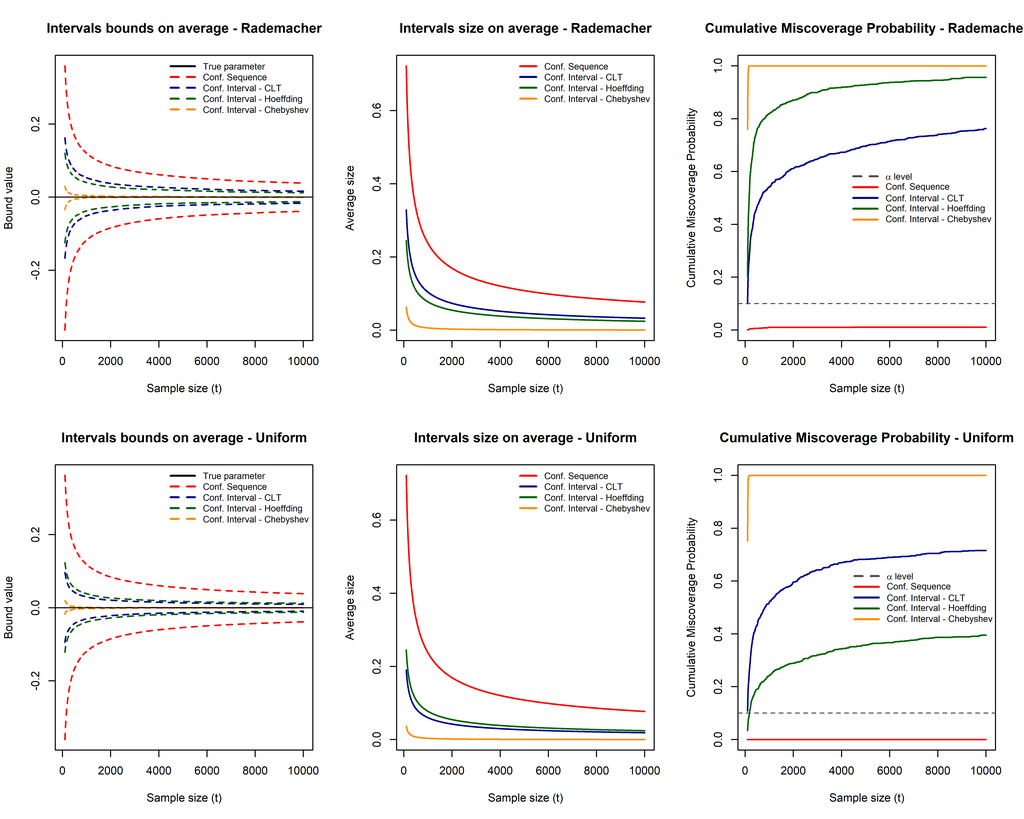

```r
# FIRST CELL OF CODE
# Calculate the normal CI (which is asymptotic for non-normal populations)
ci_norm <- function(mu_est, a, se){
  low <- mu_est - qnorm(1-(a/2))*se
  up <- mu_est + qnorm(1-(a/2))*se
  return(c(lower = low, upper = up))
}

# Calculate the Hoeffding CI
ci_hoef <- function(mu_est, a, csize){
  low <- mu_est - sqrt(log(2/a)/(2*csize))
  up <- mu_est + sqrt(log(2/a)/(2*csize))
  return(c(lower = low, upper = up))
}

# Calculate the Chebyshev CI
ci_cheb <- function(mu_est, a, se, csize){
  low <- mu_est - se/(sqrt(csize*a))
  up <- mu_est + se/(sqrt(csize*a))
  return(c(lower = low, upper = up))
}

# Calculate Sub-Gaussian CS
cs_subnorm <- function(mu_est, a, csize){
  low <- mu_est - (1.7*sqrt((log(log(2*csize))+0.72*log(5.2/a))/csize))
  up <- mu_est + (1.7*sqrt((log(log(2*csize))+0.72*log(5.2/a))/csize))
  return(c(lower = low, upper = up))
}

# Calculate Asymptotic Sub-Gaussian CS
cs_asym_subnorm <- function(mu_est, var_est, a, csize){
  low <- mu_est - 1.7*var_est*sqrt((log(log(2*csize))+0.72*log(10.4/a))/csize)
  up <- mu_est + 1.7*var_est*sqrt((log(log(2*csize))+0.72*log(10.4/a))/csize)
  return(c(lower = low, upper = up))
}

# ---- SIMULATION ----
M <- 1000 # arbitrary - simulation size
t_min <- 100 # arbitrary - minimum sample size
t_max <- 10000 # arbitrary - maximum sample size
true_mu <- 0 # arbitrary - true mean
alpha <- 0.1 # arbitrary - miscoverage probability of ci/cs

# Initialize matrices to store bounds at each time
# This is done for both the populations
ci_n_mat_low_rade <-  matrix(NA, nrow = M, ncol = t_max-t_min+1)
ci_n_mat_up_rade <- matrix(NA, nrow = M, ncol = t_max-t_min+1)
ci_h_mat_low_rade <-  matrix(NA, nrow = M, ncol = t_max-t_min+1)
ci_h_mat_up_rade <- matrix(NA, nrow = M, ncol = t_max-t_min+1)
ci_c_mat_low_rade <-  matrix(NA, nrow = M, ncol = t_max-t_min+1)
ci_c_mat_up_rade <- matrix(NA, nrow = M, ncol = t_max-t_min+1)
cs_mat_low_rade <- matrix(NA, nrow = M, ncol = t_max-t_min+1)
cs_mat_up_rade <- matrix(NA, nrow = M, ncol = t_max-t_min+1)

ci_n_mat_low_unif <-  matrix(NA, nrow = M, ncol = t_max-t_min+1)
ci_n_mat_up_unif <- matrix(NA, nrow = M, ncol = t_max-t_min+1)
ci_h_mat_low_unif <-  matrix(NA, nrow = M, ncol = t_max-t_min+1)
ci_h_mat_up_unif <- matrix(NA, nrow = M, ncol = t_max-t_min+1)
ci_c_mat_low_unif <-  matrix(NA, nrow = M, ncol = t_max-t_min+1)
ci_c_mat_up_unif <- matrix(NA, nrow = M, ncol = t_max-t_min+1)
cs_mat_low_unif <- matrix(NA, nrow = M, ncol = t_max-t_min+1)
cs_mat_up_unif <- matrix(NA, nrow = M, ncol = t_max-t_min+1)
# Set seed for reproducibility
set.seed(445)
for (m in 1:M){
  samp_rade <- c()
  samp_unif <- c()
  i = 0
  for (t in 1:t_max){
    # RADEMACHER
    samp_rade <- c(samp_rade, sample(c(-1,1), 1, replace = T))
    # BERNOULLI
    #samp <- c(samp, sample(c(0,1), 1, replace = T))
    # UNIFORM
    samp_unif <- c(samp_unif, runif(1,-1,1))
    # NORMAL WITH VARIANCE < 1
    #samp <- c(samp, rnorm(1, mean = true_mu, sd = true_sd))
    if (t >= t_min){
      i = i+1

      # CALCULATE CLT CI
      ci_norm_est_rade <- ci_norm(mean(samp_rade), a = alpha, se = sqrt(var(samp_rade)/t))
      ci_norm_est_unif <- ci_norm(mean(samp_unif), a = alpha, se = sqrt(var(samp_unif)/t))

      # CALCULATE HOEFFDING CI
      ci_hoef_est_rade <- ci_hoef(mean(samp_rade), a = alpha, csize = t)
      ci_hoef_est_unif <- ci_hoef(mean(samp_unif), a = alpha, csize = t)

      # CALCULATE CHEBYSHEV CI
      ci_cheb_est_rade <- ci_cheb(mean(samp_rade), a = alpha, se = sqrt(var(samp_rade)/t), csize = t)
      ci_cheb_est_unif <- ci_cheb(mean(samp_unif), a = alpha, se = sqrt(var(samp_unif)/t), csize = t)

      # CALCULATE CONFIDENCE SEQUENCE
      cs_subnorm_est_rade <- cs_subnorm(mean(samp_rade), a = alpha, csize = t)
      cs_subnorm_est_unif <- cs_subnorm(mean(samp_unif), a = alpha, csize = t)

      # Store results in the matrices
      ci_n_mat_low_rade[m,i] <- unname(ci_norm_est_rade['lower'])
      ci_n_mat_up_rade[m,i] <- unname(ci_norm_est_rade['upper'])
      ci_h_mat_low_rade[m,i] <- unname(ci_hoef_est_rade['lower'])
      ci_h_mat_up_rade[m,i] <- unname(ci_hoef_est_rade['upper'])
      ci_c_mat_low_rade[m,i] <- unname(ci_cheb_est_rade['lower'])
      ci_c_mat_up_rade[m,i] <- unname(ci_cheb_est_rade['upper'])
      cs_mat_low_rade[m,i] <- unname(cs_subnorm_est_rade['lower'])
      cs_mat_up_rade[m,i] <- unname(cs_subnorm_est_rade['upper'])
      ci_n_mat_low_unif[m,i] <- unname(ci_norm_est_unif['lower'])
      ci_n_mat_up_unif[m,i] <- unname(ci_norm_est_unif['upper'])
      ci_h_mat_low_unif[m,i] <- unname(ci_hoef_est_unif['lower'])
      ci_h_mat_up_unif[m,i] <- unname(ci_hoef_est_unif['upper'])
      ci_c_mat_low_unif[m,i] <- unname(ci_cheb_est_unif['lower'])
      ci_c_mat_up_unif[m,i] <- unname(ci_cheb_est_unif['upper'])
      cs_mat_low_unif[m,i] <- unname(cs_subnorm_est_unif['lower'])
      cs_mat_up_unif[m,i] <- unname(cs_subnorm_est_unif['upper'])
    }
  }
}

# Estimate miscoverage probability at every time 't'
# At every time it states if the true value of the parameter is inside the interval
# If it is so, 1 is assigned to it, otherwise 0 is assigned to it
# After that, the 'cummax' function is used to calculate if there was a miscoverage
# before each time 't'. The process is repeated for each row (simulation).
# At the end, a column-wise average is computed to estimate the miscoverage probability
# at every time 't'
ci_n_miscov_rade <- colMeans(t(apply(ci_n_mat_low_rade > true_mu | ci_n_mat_up_rade < true_mu, MARGIN = 1, cummax)))
ci_h_miscov_rade <- colMeans(t(apply(ci_h_mat_low_rade > true_mu | ci_h_mat_up_rade < true_mu, MARGIN = 1, cummax)))
ci_c_miscov_rade <- colMeans(t(apply(ci_c_mat_low_rade > true_mu | ci_c_mat_up_rade < true_mu, MARGIN = 1, cummax)))
cs_miscov_rade <- colMeans(t(apply(cs_mat_low_rade > true_mu | cs_mat_up_rade < true_mu, MARGIN = 1, cummax)))
ci_n_miscov_unif <- colMeans(t(apply(ci_n_mat_low_unif > true_mu | ci_n_mat_up_unif < true_mu, MARGIN = 1, cummax)))
ci_h_miscov_unif <- colMeans(t(apply(ci_h_mat_low_unif > true_mu | ci_h_mat_up_unif < true_mu, MARGIN = 1, cummax)))
ci_c_miscov_unif <- colMeans(t(apply(ci_c_mat_low_unif > true_mu | ci_c_mat_up_unif < true_mu, MARGIN = 1, cummax)))
cs_miscov_unif <- colMeans(t(apply(cs_mat_low_unif > true_mu | cs_mat_up_unif < true_mu, MARGIN = 1, cummax)))

# Calculate the average size at every time 't'
ci_n_size_rade <- ci_n_mat_up_rade - ci_n_mat_low_rade
ci_h_size_rade <- ci_h_mat_up_rade - ci_h_mat_low_rade
ci_c_size_rade <- ci_c_mat_up_rade - ci_c_mat_low_rade
cs_size_rade <- cs_mat_up_rade - cs_mat_low_rade
ci_n_size_unif <- ci_n_mat_up_unif - ci_n_mat_low_unif
ci_h_size_unif <- ci_h_mat_up_unif - ci_h_mat_low_unif
ci_c_size_unif <- ci_c_mat_up_unif - ci_c_mat_low_unif
cs_size_unif <- cs_mat_up_unif - cs_mat_low_unif
ci_n_avg_size_rade <- apply(ci_n_size_rade, MARGIN = 2, FUN = mean)
ci_h_avg_size_rade <- apply(ci_h_size_rade, MARGIN = 2, FUN = mean)
ci_c_avg_size_rade <- apply(ci_c_size_rade, MARGIN = 2, FUN = mean)
cs_avg_size_rade <- apply(cs_size_rade, MARGIN = 2, FUN = mean)
ci_n_avg_size_unif <- apply(ci_n_size_unif, MARGIN = 2, FUN = mean)
ci_h_avg_size_unif <- apply(ci_h_size_unif, MARGIN = 2, FUN = mean)
ci_c_avg_size_unif <- apply(ci_c_size_unif, MARGIN = 2, FUN = mean)
cs_avg_size_unif <- apply(cs_size_unif, MARGIN = 2, FUN = mean)

# Calculate average bounds at every time 't'
ci_n_avg_lows_rade <- apply(ci_n_mat_low_rade, MARGIN = 2, FUN = mean)
ci_n_avg_ups_rade <- apply(ci_n_mat_up_rade, MARGIN = 2, FUN = mean)
ci_h_avg_lows_rade <- apply(ci_h_mat_low_rade, MARGIN = 2, FUN = mean)
ci_h_avg_ups_rade <- apply(ci_h_mat_up_rade, MARGIN = 2, FUN = mean)
ci_c_avg_lows_rade <- apply(ci_c_mat_low_rade, MARGIN = 2, FUN = mean)
ci_c_avg_ups_rade <- apply(ci_c_mat_up_rade, MARGIN = 2, FUN = mean)
cs_avg_lows_rade <- apply(cs_mat_low_rade, MARGIN = 2, FUN = mean)
cs_avg_ups_rade <- apply(cs_mat_up_rade, MARGIN = 2, FUN = mean)
ci_n_avg_lows_unif <- apply(ci_n_mat_low_unif, MARGIN = 2, FUN = mean)
ci_n_avg_ups_unif <- apply(ci_n_mat_up_unif, MARGIN = 2, FUN = mean)
ci_h_avg_lows_unif <- apply(ci_h_mat_low_unif, MARGIN = 2, FUN = mean)
ci_h_avg_ups_unif <- apply(ci_h_mat_up_unif, MARGIN = 2, FUN = mean)
ci_c_avg_lows_unif <- apply(ci_c_mat_low_unif, MARGIN = 2, FUN = mean)
ci_c_avg_ups_unif <- apply(ci_c_mat_up_unif, MARGIN = 2, FUN = mean)
cs_avg_lows_unif <- apply(cs_mat_low_unif, MARGIN = 2, FUN = mean)
cs_avg_ups_unif <- apply(cs_mat_up_unif, MARGIN = 2, FUN = mean)

# Export the useful data in a CSV file, because the simulation runtime is really long
summaries_final <- cbind(ci_n_avg_lows_rade,ci_n_avg_ups_rade,ci_h_avg_lows_rade,ci_h_avg_ups_rade,ci_c_avg_lows_rade,ci_c_avg_ups_rade, cs_avg_lows_rade,cs_avg_ups_rade,ci_n_avg_size_rade,ci_h_avg_size_rade,ci_c_avg_size_rade,cs_avg_size_rade,ci_n_miscov_rade,ci_h_miscov_rade,ci_c_miscov_rade,cs_miscov_rade,ci_n_avg_lows_unif,ci_n_avg_ups_unif,ci_h_avg_lows_unif,ci_h_avg_ups_unif,ci_c_avg_lows_unif,ci_c_avg_ups_unif, cs_avg_lows_unif,cs_avg_ups_unif,ci_n_avg_size_unif,ci_h_avg_size_unif,ci_c_avg_size_unif,cs_avg_size_unif,ci_n_miscov_unif,ci_h_miscov_unif,ci_c_miscov_unif,cs_miscov_unif)

write.csv(summaries_final, file = 'summaries.csv')
```

As can be deduces from the plots, in both cases the **Confidence Sequence retains a cumulative miscoverage probability under the target (0.1) at all sample sizes**. The point-wise confidence intervals’ cumulative miscoverage probability seems to increase like a logarithm, starting near the target and ending largely over it. An exception is the Chebyshev CI, which retains the worst possible performances even with samples of a modest size.  
The advantage given by the Confidence Sequence comes with “a cost”: the confidence interval, on average, is much larger than the pointwise CIs at every sample size.  
This design prevents p-hacking during sequential experiments: it is crucial to declare if a treatment has got an effect only when it is so.

### References

- [Time-uniform Chernoff bounds via nonnegative supermartingales](https://arxiv.org/pdf/1808.03204.pdf)
- [Subgaussian random variables: An espository note](https://www.stat.cmu.edu/~arinaldo/36788/subgaussians.pdf)
- [A note on Sub-Gaussian Random Variables](https://eprint.iacr.org/2019/520.pdf)
- [Time-uniform central limit theory and asymptotic confidence sequences](https://arxiv.org/pdf/2103.06476.pdf)
- [Time-uniform, nonparametric, nonasymptotic confidence sequences](https://arxiv.org/pdf/1810.08240.pdf)
- [On strict sub-Gaussianity, optimal proxy variance and symmetry for bounded random variables](https://arxiv.org/pdf/1901.09188.pdf)
- [p-Hacking and False Discovery in A/B Testing](https://thearf-org-unified-admin.s3.amazonaws.com/MSI/2020/06/MSI_Report_18-130-1.pdf)

## Exercise 2: Environmental sounds and Mood Experiment

Many researches and papers tell us that the intricate relationship between our sensory experiences and emotional well-being has long been a subject of both scientific inquiry and philosophical speculation. Among the myriad sensory inputs, auditory stimuli (particularly environmental sounds) play a pivotal role in shaping our mood and psychological state.  
This report delves into a personal experimental investigation aimed at unraveling the impact of two distinct categories of environmental sounds, natural and urban, on the daily mood fluctuations of an individual.Environmental sounds, ranging from the serene chirping of birds and the gentle rustling of leaves to the incessant hum of city traffic and urban bustle, envelop our daily lives.  
Can the auditory landscape to which we are exposed subtly, yet significantly, influence our emotional equilibrium? Prior research (as can be seen from the references) has indicated that natural sounds often have a soothing effect, promoting relaxation and reducing stress, whereas urban noises can exacerbate anxiety and disrupt mental tranquility. However, the extent and nature of these effects can be profoundly personal and subject to individual variability and this is why we are planning to do this experiment.  
First of all the question we are trying to answer to, so our **research question**, is the following:

**Do ambient sounds heard at the start of the day have an impact on my mood? If they do, is the effect also visible at the end of the day?**

The aim of the experiment is answer to the above question, but let’s delve a bit more into the key elements of the experiment.  
The first important key is the **population** we want to be part of the experiment: since it would be realistically difficult to get a sample such that the results could be generalized, only **one member of our group** (so one of us) will be the person who will undergo the experiment.  
Another important aspect is the explanation of the **methodology**:

- The experiment will take a total of **20 days** which will be split up as follows:
  - During the **first week** the person will **record his/her mood without sounds exposure two times per day**: the first one early in the morning, when he/she will wake up and the second one before going to sleep, so in the evening.
  - After this first week **6 days** will follow in which the person will wake up in the morning and **listen to a playlist of about 10 minutes with sounds of nature** (taken randomly from a set of sounds including sea waves, birds singing, leaves rustling, breeze).
  - At this point we have scheduled a break day in which the person undergoing the experiment will be left free before proceeding with the second part of the experiment.
  - The last part of the experiment will take **6 days** in which the person will wake up in the morning and **listen to a playlist of about 10 minutes with sounds of urban noise** (taken randomly from a set of sounds including traffic, people arguing on the road, man at work). Let’s clarify a few points:
  - We’ve chosen to introduce a break of one day so that the sudden change between the two different types of sounds would not have much impact on the data obtained later when listening to the urban sounds: it’s intuitive to think that if the sound of nature had a sort of effect, the mood would collapse drastically if urban sounds are listened the immediately successive day.
  - The first week will therefore be a *control week* in order to obtain a benchmark to compare with the data collected during the treatment. We’ve thought of taking two different averages: the average of the morning mood and the average of the evening mood (after a full day’s experience). This period is one week long in order to have more observations and not just one data point that could be collected as a single question to the experimenter (such as “what is your average mood”).
  - We chose to record the person’s mood twice precisely to answer the two research questions and therefore to evaluate both **if the mood changed immediately after listening** therefore when the subject is still under the effect of the acoustic stimulus and both **if the mood had remained constant during the day** and therefore if the effect of the sound had lasted long term during the day.

**EXAMPLE OF EMAIL THE PERSON UNDERGOING THE EXPERIMENT WILL RECEIVE**

**Subject**: Your daily sound experiment instructions

Dear [participant’s name],  
Thank you for participating in our sound and mood experiment. Please follow these steps:

- **Morning**: Immediately after waking up, use your **headphones** to listen to today’s sound playlist: [playlist link]. As said before, please use **headphones and close your eyes** in order to achieve a full immersion.
- **Mood Tracking**: After listening, fill out [this](https://forms.gle/Nb7bp598TfFbMqYZ7) form. **Repeat the form submission in the evening before going to bed.**

Your consistent participation is crucial. Feel free to contact us for any questions or issues.  
Thank you for your involvement!

The playlists we will send will be the following:

| [Spotify playlist day 1](http://tinyurl.com/483rcrcx) | [YouTube video day 1](http://tinyurl.com/2p9nszks) |
| --- | --- |
| [Spotify playlist day 2](http://tinyurl.com/ytxscynj) | [YouTube video day 2](http://tinyurl.com/3vzk38se) |
| [Spotify playlist day 3](http://tinyurl.com/25n2mbwe) | [YouTube video day 3](http://tinyurl.com/2fxscxwc) |
| [Spotify playlist day 4](http://tinyurl.com/y4wkzbt5) | [YouTube video day 4](http://tinyurl.com/549czbup) |
| [Spotify playlist day 5](http://tinyurl.com/4bvxkxkn) | [YouTube video day 5](http://tinyurl.com/4ks7zbpb) |
| [Spotify playlist day 6](http://tinyurl.com/mr2aezku) | [YouTube video day 6](http://tinyurl.com/2n5yvkhm) |

- **Tools and Apps** required for this experiment and **Data Collection**: In order to participate in the experiment, we expect the person to have a smartphone with an internet connection, the Spotify and YouTube apps installed and a pair of headphones for the following reasons:
  - During the first week (which we can call *control week*) the person will receive each day an email (sample follows) with a link to a Google form where **he/she will be asked to express his mood with a rating from 1 to 5 where 1 is “sad/frustrated” and 5 is “happy/relaxed”. This form must be filled out twice, once in the morning as soon as he/she gets up and once in the evening**. The email is sent at 3 A.M. to be sure that the person can read it as soon as he/she wakes up.
  - During the successive parts of the experiment he/she will receive at 3 A.M. of each day an email (sample follows) with **a link to a Spotify playlist (if they are the 6 days dedicated to listening to nature) or a link to a YouTube video (in which case they were the days in which the person must listen to urban sounds).** Also in the email he/she will find the link to a google form where **he/she will be asked to express his/her mood with a rating from 1 to 5 where 1 is “sad/frustrated” and 5 is “happy/relaxed”. This form will have to be filled out twice, once in the morning as soon as he/she gets up and once in the evening**.
  - **The sounds must be listened to with headphones in ears and with eyes closed.** This will be expressly specified in the email that the person will receive every day. We’ve chosen to adopt this mode to achieve the most immersive experience possible, as if the person was really in the place where the listened sounds were registered.
  - **Data Analysis**: after 20 days we will have collected all the useful data, therefore we will have the data collected during the control week and the data collected during the other 12 days in which the person will have listened to the sounds. Now we can formalize what we will do at this point. We will define the two following hypothesis tests:

    $$\begin{cases}
    H_0: \text{the mood of the person didn't change immediately
    after the listening} \\
    H_1: \text{the mood of the person changed immediately after the
    listening}
    \end{cases}$$
    $$\begin{cases}
    H_0^\prime: \text{the mood of the person didn't change during
    the day} \\
    H_1^\prime: \text{the mood of the person changed during the day}
    \end{cases}$$

    So, numerically speaking, we will analyze the data collected from the control week and **estimate the mood distribution** (we already know it will be a discrete distribution but we have to understand what kind of discrete distribution it will be, it could be a Bernoulli or maybe a uniform, we will know only when we have the data) to choose what type of confidence sequence to use.  
    We define $\mu_1$ as the mean of the morning distribution and $\mu_2$ as the mean of the evening distribution. Using the data about the remaining 12 days and **with the help of the confidence sequences** , we will be able to understand whether to reject the null hypothesis or not. In particular, we will reject the null hypothesis if the sample mean is outside the confidence sequence and vice-versa. In the end we will have two confidence sequences:
    - **One that will give us answers about the first hypothesis test**
    - **One that will give us answers about the second hypothesis test**

We will thus be able to draw conclusions and answer the two research questions.

### References

- [The impact of the acoustic environment on human emotion and experience: A case study of worship spaces](https://journals.sagepub.com/doi/10.1177/1351010X211068850)
- [Anthropogenic Noise Source and Intensity Effects on Mood and Relaxation in Simulated Park Environments](https://www.ncbi.nlm.nih.gov/pmc/articles/PMC7591392/)
- [The association between road traffic noise and depressed mood among different ethnic and socioeconomic groups. The HELIUS study](https://www.sciencedirect.com/science/article/abs/pii/S1438463918304668)
- [The Influence of Environmental Sounds on Cognition and Mood](https://ir.lib.uwo.ca/cgi/viewcontent.cgi?article=1068&context=psych_uht)